# SD_11_RECO_REV_ADD_L4AB

Investment expenses not included on Form 990 Part 8 line 7b plus other amounts included on Form 990 Part 8 line 12 but not line 1 · Amount report

## Overview

**Description**

Total amounts; add lines 4a through 4b

**Table**

`SD-P11-T00-RECONCILIATION-REVENUE` (one)

**Location code**

`SCHED-D-PART-11-LINE-04C`

**Family**

`SCHED-D-PART-11-LINE-04C`

**Data type**

numeric (xsd: , USAmountType)

**Scope**

PC

**Status**

unreviewed

2

xpaths mapped (1 observed)

721,310

filings with a value

2013–2024

tax years observed

2

open flags (1 errors)

## Flags

| Severity | Flag | Xpath | Detail |
| --- | --- | --- | --- |
| ⚠ error | `POLARITY` | IRS990ScheduleD/RevenueNotReportedFinclStmtAmt | negated element ‘RevenueNotReportedFinclStmtAmt’ pooled with non-negated xpaths |
| ⓘ info | `UNOBSERVED` | IRS990ScheduleD/Form990ScheduleDPartXII/TotalAmountsLine4aTo4b | never observed in TY2009-2024 filings |

## Xpaths

All mapped xpaths (under /Return/ReturnData or /Return/ReturnHeader), oldest first. Charts label each series by its xpath.

| Xpath | Form | Chart label | First year | Last year | Versions | Filings | Repeats in |
| --- | --- | --- | --- | --- | --- | --- | --- |
| IRS990ScheduleD/RevenueNotReportedFinclStmtAmt | Sched D | same | 2013 | 2024 | 37 | 721,310 | 0.0% |
| IRS990ScheduleD/Form990ScheduleDPartXII/TotalAmountsLine4aTo4b | Sched D | …0ScheduleD/Form990ScheduleDPartXII/TotalAmountsLine4aTo4b |  |  |  | 0 |  |

## Coverage

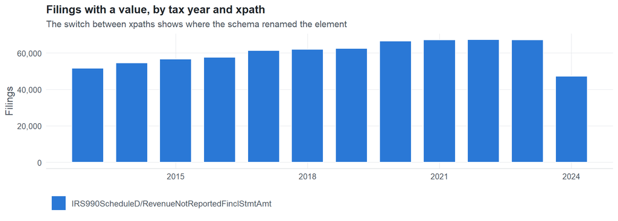

**Table view**

Table view: filings by tax year and series

| Tax year | IRS990ScheduleD/RevenueNotReportedFinclStmtAmt |
| --- | --- |
| 2013 | 51,605 |
| 2014 | 54,520 |
| 2015 | 56,591 |
| 2016 | 57,650 |
| 2017 | 61,267 |
| 2018 | 61,911 |
| 2019 | 62,437 |
| 2020 | 66,514 |
| 2021 | 67,176 |
| 2022 | 67,253 |
| 2023 | 67,122 |
| 2024 | 47,264 |

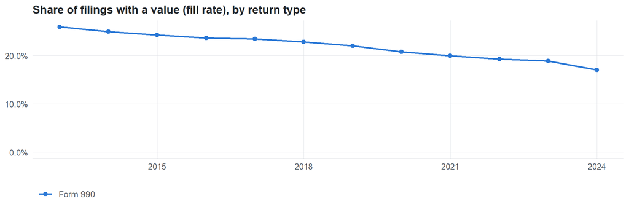

**Table view**

Table view: fill rate

| Tax year | Return type | Filings | All filings | Fill rate |
| --- | --- | --- | --- | --- |
| 2013 | Form 990 | 51,605 | 198,855 | 25.95% |
| 2014 | Form 990 | 54,520 | 218,619 | 24.94% |
| 2015 | Form 990 | 56,591 | 233,519 | 24.23% |
| 2016 | Form 990 | 57,650 | 243,903 | 23.64% |
| 2017 | Form 990 | 61,267 | 261,612 | 23.42% |
| 2018 | Form 990 | 61,911 | 271,442 | 22.81% |
| 2019 | Form 990 | 62,437 | 283,694 | 22.01% |
| 2020 | Form 990 | 66,514 | 320,342 | 20.76% |
| 2021 | Form 990 | 67,176 | 336,480 | 19.96% |
| 2022 | Form 990 | 67,253 | 349,055 | 19.27% |
| 2023 | Form 990 | 67,122 | 354,768 | 18.92% |
| 2024 | Form 990 | 47,264 | 277,298 | 17.04% |

## Values

| Result | Check | Detail |
| --- | --- | --- |
| ✓ pass | Values parse as numbers | 100.0% of values are numeric |
| ▲ warn | No sudden change in the median between adjacent years | largest change 9.5x (IRS990ScheduleD/RevenueNotReportedFinclStmtAmt, 990, TY2016) |
| ✓ pass | Pooled xpaths are on the same scale (same return type) | largest ratio of medians between xpaths: 1.0x |
| ⓘ info | Sign convention | 9.3% of values are negative (fine for net amounts) |

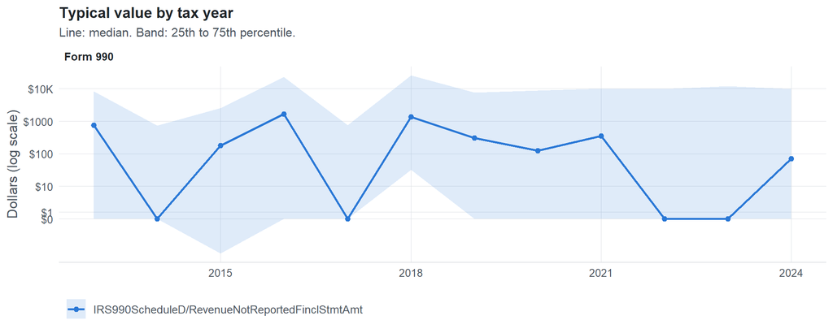

**Table view**

Table view: quartiles by tax year

| Series | Return | Tax year | Filings | P25 | Median | P75 |
| --- | --- | --- | --- | --- | --- | --- |
| IRS990ScheduleD/RevenueNotReportedFinclStmtAmt | 990 | 2013 | 51,605 | 0 | 764.74 | 8,300 |
| IRS990ScheduleD/RevenueNotReportedFinclStmtAmt | 990 | 2014 | 54,520 | 0 | 0 | 737.54 |
| IRS990ScheduleD/RevenueNotReportedFinclStmtAmt | 990 | 2015 | 56,591 | -11.23 | 177.92 | 2,548 |
| IRS990ScheduleD/RevenueNotReportedFinclStmtAmt | 990 | 2016 | 57,650 | 0 | 1,683 | 23,081 |
| IRS990ScheduleD/RevenueNotReportedFinclStmtAmt | 990 | 2017 | 61,267 | 0 | 0 | 759.16 |
| IRS990ScheduleD/RevenueNotReportedFinclStmtAmt | 990 | 2018 | 61,911 | 32.67 | 1,366 | 25,715 |
| IRS990ScheduleD/RevenueNotReportedFinclStmtAmt | 990 | 2019 | 62,437 | 0 | 310.59 | 7,606 |
| IRS990ScheduleD/RevenueNotReportedFinclStmtAmt | 990 | 2020 | 66,514 | 0 | 124.08 | 8,874 |
| IRS990ScheduleD/RevenueNotReportedFinclStmtAmt | 990 | 2021 | 67,176 | 0 | 356.91 | 10,036 |
| IRS990ScheduleD/RevenueNotReportedFinclStmtAmt | 990 | 2022 | 67,253 | 0 | 0 | 9,894 |
| IRS990ScheduleD/RevenueNotReportedFinclStmtAmt | 990 | 2023 | 67,122 | 0 | 0 | 11,867 |
| IRS990ScheduleD/RevenueNotReportedFinclStmtAmt | 990 | 2024 | 47,264 | 0 | 71.01 | 9,747 |

Summary by xpath and return type (all years)

| Series | Return | Filings | % numeric | % zero | % negative | Median (typical year) | P99 (typical year) |
| --- | --- | --- | --- | --- | --- | --- | --- |
| IRS990ScheduleD/RevenueNotReportedFinclStmtAmt | 990 | 721,310 | 100 | 60.8 | 9.3 | 0 | 11040868 |

## Examples

| Tax year | Return | Xpath | Organization | Value | Source |
| --- | --- | --- | --- | --- | --- |
| 2024 | 990 | IRS990ScheduleD/RevenueNotReportedFinclStmtAmt | GIRL SCOUTS OF KANSAS HEARTLAND INC | 37977 | [XML](https://gt990datalake-rawdata.s3.amazonaws.com/EfileData/XmlFiles/202630479349301123_public.xml) |
| 2023 | 990 | IRS990ScheduleD/RevenueNotReportedFinclStmtAmt | ZEPF CENTER | -25354 | [XML](https://gt990datalake-rawdata.s3.amazonaws.com/EfileData/XmlFiles/202423399349300887_public.xml) |
| 2022 | 990 | IRS990ScheduleD/RevenueNotReportedFinclStmtAmt | CANTERBURY TOWER INC | 83973 | [XML](https://gt990datalake-rawdata.s3.amazonaws.com/EfileData/XmlFiles/202332979349301963_public.xml) |
| 2021 | 990 | IRS990ScheduleD/RevenueNotReportedFinclStmtAmt | AFRICA NETWORK FOR ANIMAL WELFARE- USA | 0 | [XML](https://gt990datalake-rawdata.s3.amazonaws.com/EfileData/XmlFiles/202222209349300402_public.xml) |
| 2020 | 990 | IRS990ScheduleD/RevenueNotReportedFinclStmtAmt | CHARLOTTE HARBOR WATER ASSOCIATION INC | 0 | [XML](https://gt990datalake-rawdata.s3.amazonaws.com/EfileData/XmlFiles/202132739349301608_public.xml) |
| 2019 | 990 | IRS990ScheduleD/RevenueNotReportedFinclStmtAmt | INDEPENDENCE IV INC | 0 | [XML](https://gt990datalake-rawdata.s3.amazonaws.com/EfileData/XmlFiles/202111349349304201_public.xml) |
| 2018 | 990 | IRS990ScheduleD/RevenueNotReportedFinclStmtAmt | UA LOCAL NO 159 | 8000 | [XML](https://gt990datalake-rawdata.s3.amazonaws.com/EfileData/XmlFiles/202000509349301025_public.xml) |
| 2017 | 990 | IRS990ScheduleD/RevenueNotReportedFinclStmtAmt | MOLOKAI OHANA HEALTH CARE INC | 0 | [XML](https://gt990datalake-rawdata.s3.amazonaws.com/EfileData/XmlFiles/201941359349314364_public.xml) |
| 2016 | 990 | IRS990ScheduleD/RevenueNotReportedFinclStmtAmt | Bellin Psychiatric Center | 0 | [XML](https://gt990datalake-rawdata.s3.amazonaws.com/EfileData/XmlFiles/201812279349301906_public.xml) |
| 2015 | 990 | IRS990ScheduleD/RevenueNotReportedFinclStmtAmt | FIAT LUX RISK AND INSURANCE COMPANY | 10794029 | [XML](https://gt990datalake-rawdata.s3.amazonaws.com/EfileData/XmlFiles/201721329349305242_public.xml) |
| 2014 | 990 | IRS990ScheduleD/RevenueNotReportedFinclStmtAmt | ROCHESTER AREA NEIGHBORHOOD HOUSE | 0 | [XML](https://gt990datalake-rawdata.s3.amazonaws.com/EfileData/XmlFiles/201543139349302224_public.xml) |
| 2013 | 990 | IRS990ScheduleD/RevenueNotReportedFinclStmtAmt | EAST BALTIMORE COMMUNITY SCHOOL INC | 0 | [XML](https://gt990datalake-rawdata.s3.amazonaws.com/EfileData/XmlFiles/201541359349303049_public.xml) |

## Reviewer checklist

- The definition matches the form line and instructions for every xpath’s schema years.
- Every xpath pooled here measures the same thing on the 990 and 990-EZ (close enough for analysis).
- The coverage chart has no unexplained gaps or jumps between tax years.
- Each open flag is fixed, or accepted with a note in validation_log.csv.
- Values are whole dollars, not thousands, and not a percentage.
- Current year / prior year and beginning / end of year match the variable name (CY, PY, BOY, EOY).
- Negative values are expected only for net amounts (gains, net income, fund balances).
- The 990 and 990-EZ medians differ only as much as the filer populations do.

Record the review as a row in `inst/extdata/src/validation_log.csv` (variable_name, reviewer, date, status, note). Evidence built 2026-09-23 17:09:04 MST from the ef2 DuckDB builds (tax years 2009–2024).